# Lab 1

Task 1: Part 1: X - Income, Y - Life expency, color - world region, size - population

Part: 2

```python
import pandas as pd
df = pd.read_csv("Data/q1data.csv")
#| eco : true
```

Part 3

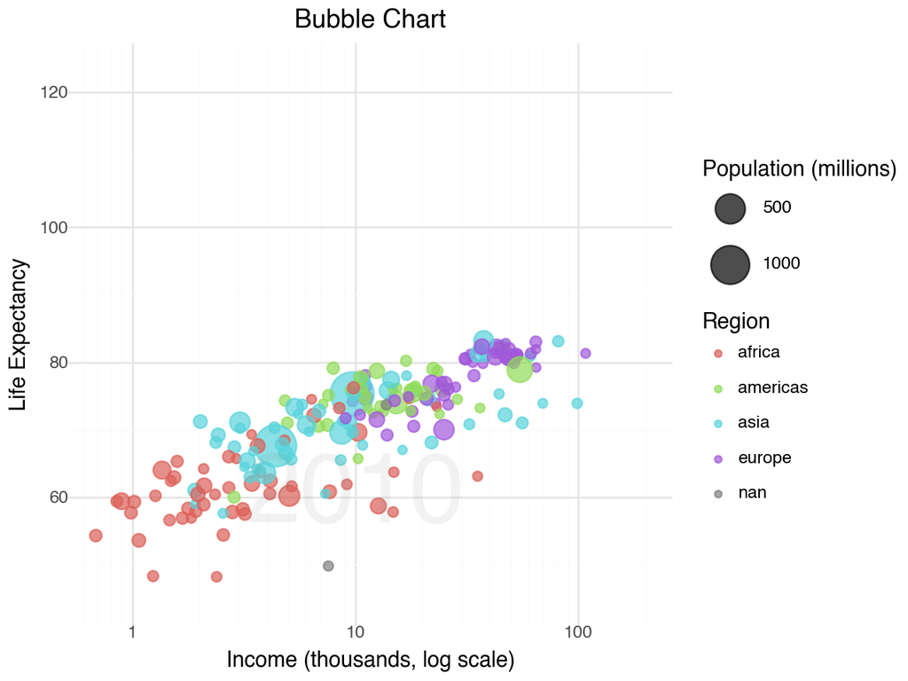

```python
import pandas as pd
from plotnine import ggplot, aes, geom_point, scale_x_log10, scale_size_continuous, \
    labs, theme_minimal, guides, guide_legend, annotate, expand_limits, scale_y_continuous
df_2010 = df[df["year"] == 2010]
df_2010 = df[df["year"] == 2010].copy()
df_2010["income"] = df_2010["income"] / 1000        # thousands of dollars
df_2010["population"] = df_2010["population"] / 1e6 # millions

(
    ggplot(df_2010, aes(x="income", y="life_exp",
                        size="population", color="four_regions"))
    + geom_point(alpha=0.7)
    + scale_x_log10()
    + scale_size_continuous(range=(2, 12))
    + labs(
        title="Bubble Chart",
        x="Income (thousands, log scale)",
        y="Life Expectancy",
        color="Region",
        size="Population (millions)"
    )
    + guides(size=guide_legend(title="Population (millions)"))
    + theme_minimal()
    + annotate("text", x=10, y=60, label="2010", size=50, alpha=0.1, color="gray")
    + expand_limits(x=200, y=120)
    + scale_y_continuous(expand=(0.1, 0.1))
)
```

Part 4

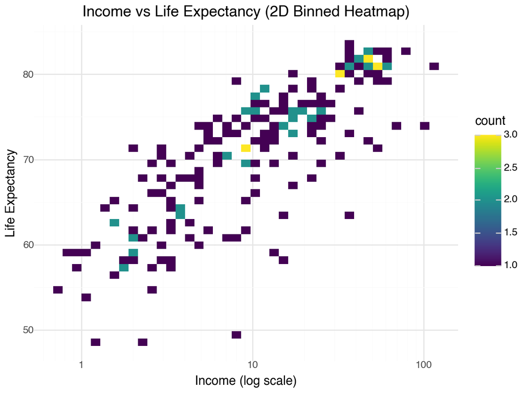

```python
import pandas as pd
from plotnine import ggplot, aes, stat_bin_2d, scale_x_log10, labs, theme_minimal,expand_limits, scale_y_continuous
(
    ggplot(df_2010, aes(x="income", y="life_exp"))
    + stat_bin_2d(bins=40)
    + scale_x_log10()
    + labs(
        title="Income vs Life Expectancy (2D Binned Heatmap)",
        x="Income (log scale)", y="Life Expectancy"
    )
    + theme_minimal()
)
```

Plots not using geom_point for this type of data is not as good as the best way to show off this data is with a scatter plot, which is the core of geom_point

TASK 2 Part 1: X- Exports (%), Y- Imports, color - world regions, size - energy use Part 2:

```python
import pandas as pd
df1 = pd.read_csv("Data/q2data.csv")
#| eco : true
```

Part 3

```python
import pandas as pd
from plotnine import (
    ggplot, aes, geom_point, scale_x_log10, scale_size_continuous,
    labs, theme_minimal, guides, guide_legend, theme, expand_limits, scale_y_continuous
)
df_1997 = df1[df1["year"] == 1997]
df_1997["energy"] = pd.to_numeric(df_1997["energy"], errors="coerce")
plot_df = (
     df_1997
    .dropna(subset=["exports", "imports", "energy", "four_regions"])
    .loc[lambda d: (d["exports"] > 0) & (d["energy"] > 0)]
)
```

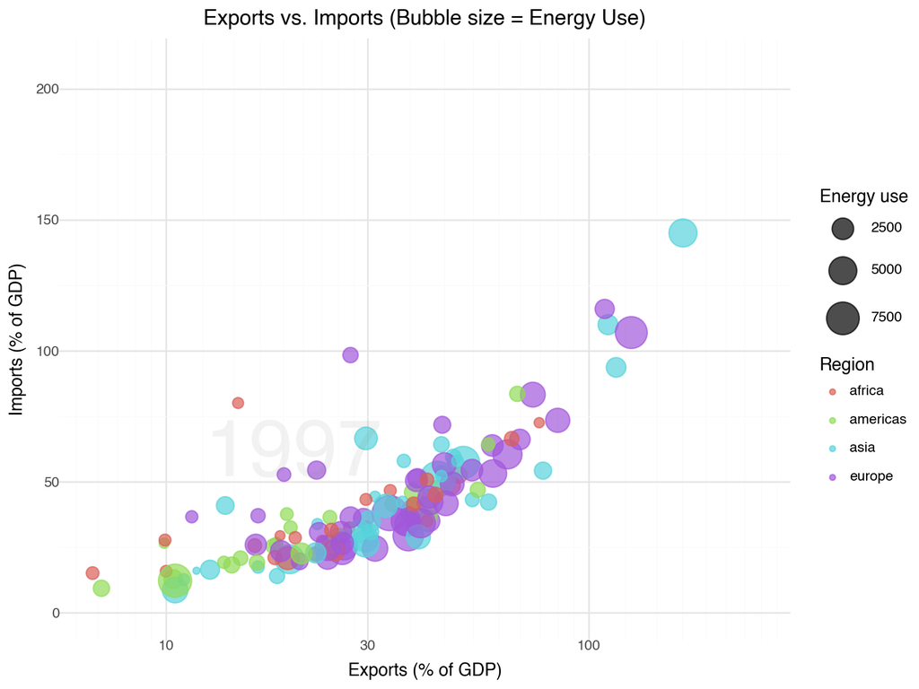

```python
(
    ggplot(plot_df, aes(x="exports", y="imports", size="energy", color="four_regions"))
    + geom_point(alpha=0.7)
    + scale_x_log10()  # exports is % of GDP; log scale helps spread small values
    + scale_size_continuous(range=(2, 12))
    + labs(
        title="Exports vs. Imports (Bubble size = Energy Use)",
        x="Exports (% of GDP)",
        y="Imports (% of GDP)",
        color="Region",
        size="Energy use"
    )
    + guides(size=guide_legend(title="Energy use"))
    + theme_minimal()
    + theme(figure_size=(8, 6))
    + annotate("text", x=20, y=60, label="1997", size=50, alpha=0.1, color="gray")
    + expand_limits(x=250, y=200)
    + scale_y_continuous(expand=(0.1, 0.1))
)
```

Part 4

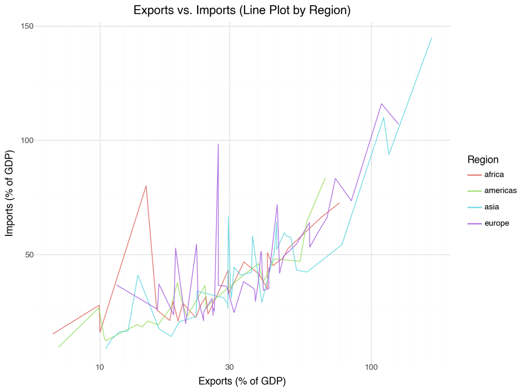

```python
import pandas as pd
from plotnine import (
    ggplot, aes, geom_line, scale_x_log10, scale_size_continuous,
    labs, theme_minimal, guides, guide_legend, theme
)
(
    ggplot(plot_df, aes(x="exports", y="imports", color="four_regions", group="four_regions"))
    + geom_line(alpha=0.8)
    + scale_x_log10()
    + labs(
        title="Exports vs. Imports (Line Plot by Region)",
        x="Exports (% of GDP)",
        y="Imports (% of GDP)",
        color="Region"
    )
    + theme_minimal()
    + theme(figure_size=(8, 6))
)
```

Similar to Task 1 part 4, using a line chart is not aas good as geom_point as this type of relationship needs to be somesort of scatter plot which is based in geom_point

TASK 3: Part 1: X= Individuals using the internet, Y= GDP cpita, color= wolrd region, size = income Part 2:

```python
import pandas as pd
df2 = pd.read_csv("Data/q3data.csv")
#| eco : true
```

Part 3:

```python
import pandas as pd
from plotnine import ggplot, aes, geom_point, scale_y_log10, scale_size_continuous, \
    labs, theme_minimal, guides, guide_legend
df_2001 = df2[df2["year"] == 2001]
```

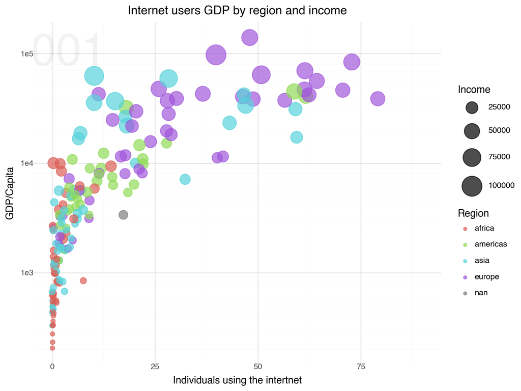

```python
(
    ggplot(df_2001, aes(x="internet_users", y="gdp", size="income", color="four_regions"))
    + geom_point(alpha=0.7)
    + scale_y_log10()
    + scale_size_continuous(range=(2, 12))
    + labs(
        title="Internet users GDP by region and income",
        x="Individuals using the intertnet",
        y="GDP/Capita",
        color="Region",
        size="Income"
    )
    + guides(size=guide_legend(title="Income"))
    + theme_minimal()
    + theme(figure_size=(8, 6))
    + annotate("text", x=1, y=100000, label="2001", size=50, alpha=0.1, color="gray")
    + expand_limits(x=90, y=100000)
)
```

Part 4:

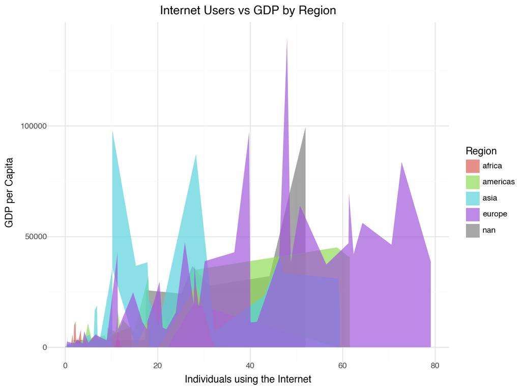

```python
from plotnine import ggplot, aes, geom_area, labs, theme_minimal, theme

(
    ggplot(df_2001, aes(x="internet_users", y="gdp", fill="four_regions"))
    + geom_area(alpha=0.7)
    + labs(
        title="Internet Users vs GDP by Region",
        x="Individuals using the Internet",
        y="GDP per Capita",
        fill="Region"
    )
    + theme_minimal()
    + theme(figure_size=(8, 6))
)
```

Similar to Task 1 and 2 part 4, using a stacked area chart is not aas good as geom_point as this type of relationship needs to be somesort of scatter plot which is based in geom_point